# Chapter 3

Annina Haveinen

11/3/2018

This exercise is based on a data set about student achievement in secondary education in two Portuguese schools. Data includes student grades,demographic, social and school related features and it was collected by using school reports and questionnaires. The data “alc” is a subset of this data, with alcohol use on weekdays and weekends combined by averaging and high use defined >2 (scale: 1 = very low to 5 very high). Links to [original dataset](https://archive.ics.uci.edu/ml/datasets/Student+Performance) and [publication](http://www3.dsi.uminho.pt/pcortez/student.pdf).

### *Exploring the data*

Readning the wrangled data from local disk.

```r
alc<-read.table("/Users/Annina/Documents/GitHub/IODS-project/Data/alc.txt",sep=";")
```

Next lets explore the data:

```r
dim(alc)
```

```
## [1] 382  35
```

```r
colnames(alc)
```

```
##  [1] "school"     "sex"        "age"        "address"    "famsize"
##  [6] "Pstatus"    "Medu"       "Fedu"       "Mjob"       "Fjob"
## [11] "reason"     "nursery"    "internet"   "guardian"   "traveltime"
## [16] "studytime"  "failures"   "schoolsup"  "famsup"     "paid"
## [21] "activities" "higher"     "romantic"   "famrel"     "freetime"
## [26] "goout"      "Dalc"       "Walc"       "health"     "absences"
## [31] "G1"         "G2"         "G3"         "alc_use"    "high_use"
```

```r
summary(alc$high_use) # = alc_use >2 = TRUE
```

```
##    Mode   FALSE    TRUE
## logical     268     114
```

The response variable of interest is the binary variable “high_use” (TRUE/FALSE) correspoinding to alcohol use >2 on a scale from 1-5.

My hypotesis is that high alcohol use is correlated to the variables; “goout”,“sex” and “abscences” and that these could be used in a model for predicting high use. My hypothesis is that male students drink more than female students. People who go out more drink more alcohol and that people that have more abscences from school drink more alcohol.

Lets look at the chosen variables:

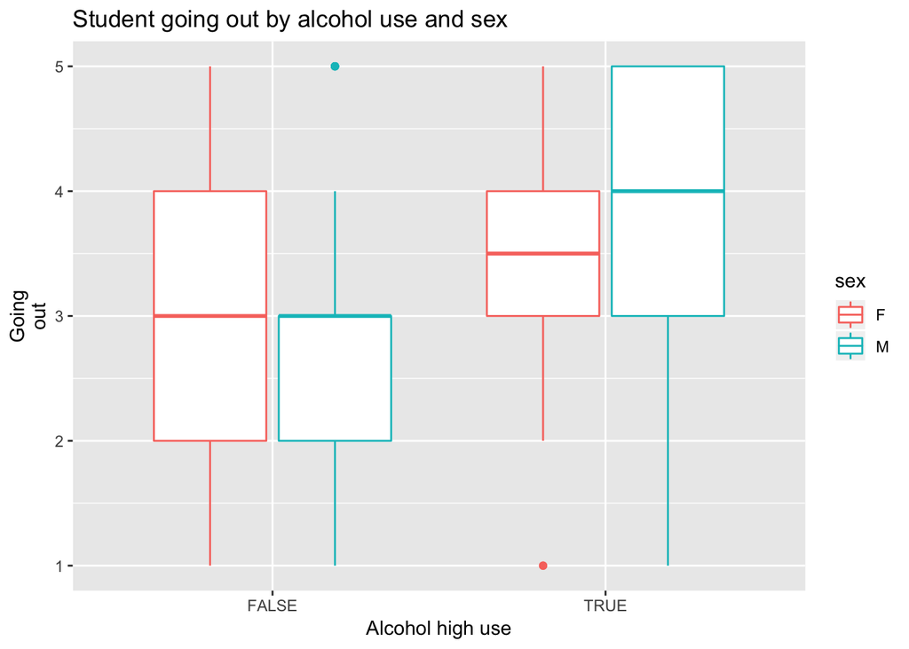

```r
p1 <- ggplot(alc, aes(x=high_use, y = goout, col=sex))+geom_boxplot()+ylab("Going
out")+xlab("Alcohol high use")+ggtitle("Student going out by alcohol use and sex")
p1
```

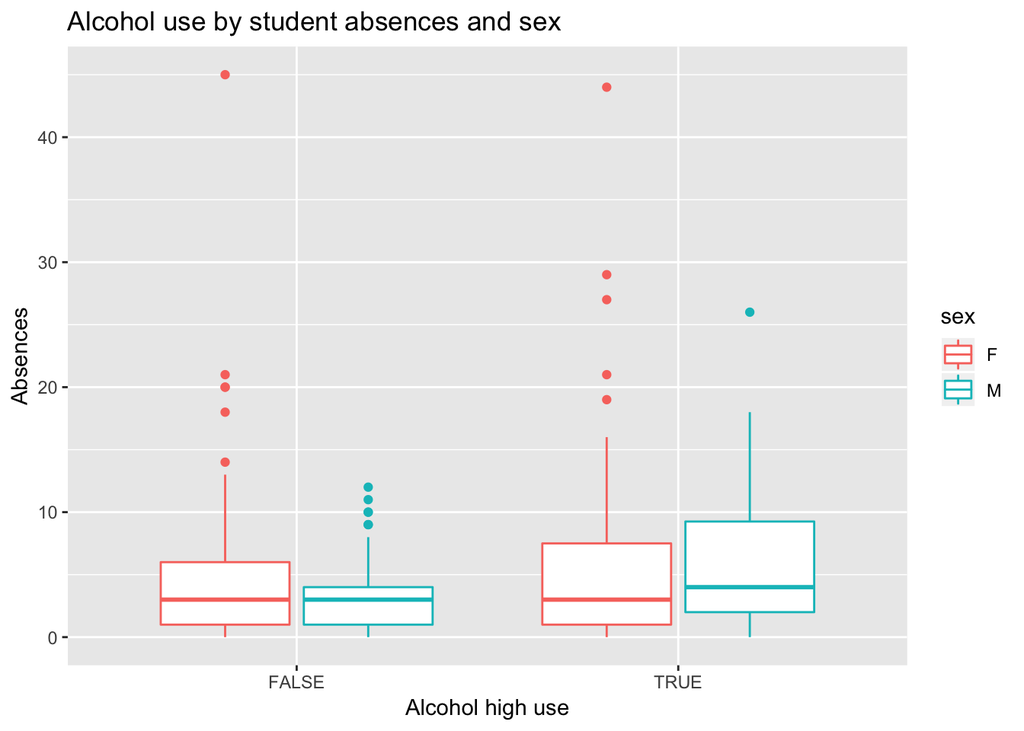

```r
p2 <- ggplot(alc, aes(high_use, absences, col=sex))+ylab("Absences")+xlab("Alcohol high use")+geom_boxplot()+ggtitle("Alcohol use by student absences and sex")

p2 #numeric 0-93 days
```

In this boxplot it looks like the students having high alcohol use have somewhat more absences.

```r
table(alc$high_use,alc$sex)
```

```
##
##           F   M
##   FALSE 156 112
##   TRUE   42  72
```

In this table we see that of the male students 38% and 21% of the women fall in the high alcohol use group. Of the whole data 30% are in the high use group.

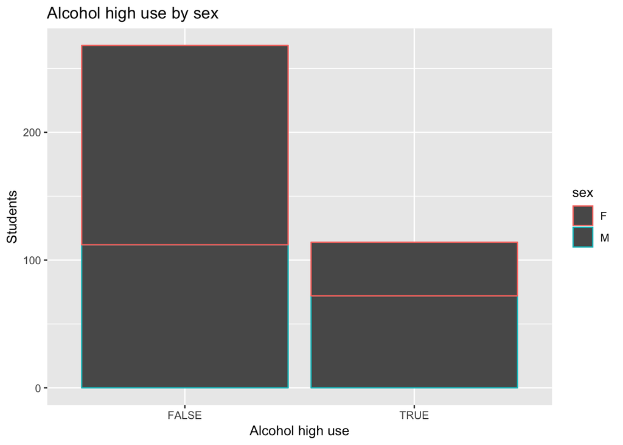

```r
p3 <- ggplot(alc, aes(high_use, col=sex))+geom_bar()+ylab(
"Students")+xlab("Alcohol high use")+ggtitle("Alcohol high use by sex")
p3
```

In this barplot we se that more men than women are in the high use group.